# [Prediction Assignment] Weight Lifting Exercise

Zhi Xiong Chong

2015-12-28

## Introduction

Large amount of data about personal activity is collected using devices in a relatively inexpensive manner. Following the study of Human Activity Recognition (HAR) by Groupware@LES (http://groupware.les.inf.puc-rio.br/har), we obtain both the training and test data.

According to the study, 6 young health participants were asked to perform one set of 10 repetitions of the Unilateral Dumbbell Biceps Curl in five different fashions: exactly according to the specification (Class A), throwing the elbows to the front (Class B), lifting the dumbbell only halfway (Class C), lowering the dumbbell only halfway (Class D) and throwing the hips to the front (Class E).

Our goal here is to predict the manner in which these 6 individuals did the exercise, dictated by the `classe` variable in the training set.

This report descibes:

1. Variables used for prediction.
2. Method taken to build the prediction model
3. Usage of cross validation
4. Expected out-of-sample error
5. Reasons for the choices made.

At the end of this work, the prediction model will be used to predict 20 different test cases.

Here is the process of Prediction:

1. Question
2. Input Data
3. Features
4. Algorithm
5. Parameters
6. Evaluation

The above process is followed in this work. Before we begin, we loaded up the following packages and set seed to be `123`.

```r
library(ggplot2)
library(caret)
library(randomForest)
library(rattle)
library(rpart.plot)
set.seed(123)
```

## Question

Question: “Can we predict the class of an activity taken?”

Goal: “to predict 20 different test cases labelled under the `problem_id` variable.”

## Input Data Loading and Processing

Working directory is set. Testing and training data are downloaded from the url beforehand and loaded as dataframe from the csv file. Testing and training data are briefly looked through to find out about the features available. The outcome to be investigated is labelled as `classe` in the training data.

```r
wd <- "C:/Users/User/Dropbox/Personal/Coursera/DataScience/8_PredictionMachineLearning/predmachlearn_CourseProject/"
testFile <- paste(wd, "pml-testing.csv", sep="")
trainFile <- paste(wd, "pml-training.csv", sep="")
setwd(wd)

testData <- read.table(testFile, na.strings=c("NA",""),
                      header=TRUE, sep=",")

trainData <- read.table(trainFile, na.strings=c("NA",""),
                       header=TRUE, sep=",")
```

## Data Features

```r
# Build functions that returns amount of NA/empty values in each column
nonNAs <- function(x) {
  as.vector(apply(x, 2, function(x) length(which(!is.na(x)))))
}

# Build vector of columns (with NA/empty values) to drop.
colcounter <- nonNAs(trainData)
drops <- c()
for (count in 1:length(colcounter)) {
  if (colcounter[count] < nrow(trainData)) {
    drops <- c(drops, colnames(trainData)[count])
  }
}

# Drop columns with NA/empty values, then first 8 columns
trainData <- trainData[,!(names(trainData) %in% drops)]
trainData <- trainData[,8:length(colnames(trainData))]
testData <- testData[,!(names(testData) %in% drops)]
testData <- testData[,8:length(colnames(testData))]
```

In order to ensure all the variables are useful when constructing a prediction model, we look for and remove variables with no variability at all. This can be done through the nearZeroVar function, as shown below. If any `nzv` value is `TRUE`, that particular variable will be removed. As suggested by the results below, no variable shall be removed from the current dataset.

```r
nearZeroVar(trainData, saveMetrics=T)
```

```
##                      freqRatio percentUnique zeroVar   nzv
## roll_belt             1.101904     6.7781062   FALSE FALSE
## pitch_belt            1.036082     9.3772296   FALSE FALSE
## yaw_belt              1.058480     9.9734991   FALSE FALSE
## total_accel_belt      1.063160     0.1477933   FALSE FALSE
## gyros_belt_x          1.058651     0.7134849   FALSE FALSE
## gyros_belt_y          1.144000     0.3516461   FALSE FALSE
## gyros_belt_z          1.066214     0.8612782   FALSE FALSE
## accel_belt_x          1.055412     0.8357966   FALSE FALSE
## accel_belt_y          1.113725     0.7287738   FALSE FALSE
## accel_belt_z          1.078767     1.5237998   FALSE FALSE
## magnet_belt_x         1.090141     1.6664968   FALSE FALSE
## magnet_belt_y         1.099688     1.5187035   FALSE FALSE
## magnet_belt_z         1.006369     2.3290184   FALSE FALSE
## roll_arm             52.338462    13.5256345   FALSE FALSE
## pitch_arm            87.256410    15.7323412   FALSE FALSE
## yaw_arm              33.029126    14.6570176   FALSE FALSE
## total_accel_arm       1.024526     0.3363572   FALSE FALSE
## gyros_arm_x           1.015504     3.2769341   FALSE FALSE
## gyros_arm_y           1.454369     1.9162165   FALSE FALSE
## gyros_arm_z           1.110687     1.2638875   FALSE FALSE
## accel_arm_x           1.017341     3.9598410   FALSE FALSE
## accel_arm_y           1.140187     2.7367241   FALSE FALSE
## accel_arm_z           1.128000     4.0362858   FALSE FALSE
## magnet_arm_x          1.000000     6.8239731   FALSE FALSE
## magnet_arm_y          1.056818     4.4439914   FALSE FALSE
## magnet_arm_z          1.036364     6.4468454   FALSE FALSE
## roll_dumbbell         1.022388    84.2065029   FALSE FALSE
## pitch_dumbbell        2.277372    81.7449801   FALSE FALSE
## yaw_dumbbell          1.132231    83.4828254   FALSE FALSE
## total_accel_dumbbell  1.072634     0.2191418   FALSE FALSE
## gyros_dumbbell_x      1.003268     1.2282132   FALSE FALSE
## gyros_dumbbell_y      1.264957     1.4167771   FALSE FALSE
## gyros_dumbbell_z      1.060100     1.0498420   FALSE FALSE
## accel_dumbbell_x      1.018018     2.1659362   FALSE FALSE
## accel_dumbbell_y      1.053061     2.3748853   FALSE FALSE
## accel_dumbbell_z      1.133333     2.0894914   FALSE FALSE
## magnet_dumbbell_x     1.098266     5.7486495   FALSE FALSE
## magnet_dumbbell_y     1.197740     4.3012945   FALSE FALSE
## magnet_dumbbell_z     1.020833     3.4451126   FALSE FALSE
## roll_forearm         11.589286    11.0895933   FALSE FALSE
## pitch_forearm        65.983051    14.8557741   FALSE FALSE
## yaw_forearm          15.322835    10.1467740   FALSE FALSE
## total_accel_forearm   1.128928     0.3567424   FALSE FALSE
## gyros_forearm_x       1.059273     1.5187035   FALSE FALSE
## gyros_forearm_y       1.036554     3.7763735   FALSE FALSE
## gyros_forearm_z       1.122917     1.5645704   FALSE FALSE
## accel_forearm_x       1.126437     4.0464784   FALSE FALSE
## accel_forearm_y       1.059406     5.1116094   FALSE FALSE
## accel_forearm_z       1.006250     2.9558659   FALSE FALSE
## magnet_forearm_x      1.012346     7.7667924   FALSE FALSE
## magnet_forearm_y      1.246914     9.5403119   FALSE FALSE
## magnet_forearm_z      1.000000     8.5771073   FALSE FALSE
## classe                1.469581     0.0254816   FALSE FALSE
```

```r
nearZeroVar(testData, saveMetrics=T)
```

```
##                      freqRatio percentUnique zeroVar   nzv
## roll_belt                 1.00            90   FALSE FALSE
## pitch_belt                1.00           100   FALSE FALSE
## yaw_belt                  1.00            90   FALSE FALSE
## total_accel_belt          1.20            45   FALSE FALSE
## gyros_belt_x              1.50            70   FALSE FALSE
## gyros_belt_y              2.25            30   FALSE FALSE
## gyros_belt_z              2.50            65   FALSE FALSE
## accel_belt_x              1.00            85   FALSE FALSE
## accel_belt_y              1.50            75   FALSE FALSE
## accel_belt_z              1.00            85   FALSE FALSE
## magnet_belt_x             1.00           100   FALSE FALSE
## magnet_belt_y             1.50            80   FALSE FALSE
## magnet_belt_z             1.50            80   FALSE FALSE
## roll_arm                  8.00            65   FALSE FALSE
## pitch_arm                 8.00            65   FALSE FALSE
## yaw_arm                   8.00            65   FALSE FALSE
## total_accel_arm           1.00            85   FALSE FALSE
## gyros_arm_x               2.00            95   FALSE FALSE
## gyros_arm_y               2.00            95   FALSE FALSE
## gyros_arm_z               1.00            90   FALSE FALSE
## accel_arm_x               2.00            95   FALSE FALSE
## accel_arm_y               1.00           100   FALSE FALSE
## accel_arm_z               1.00           100   FALSE FALSE
## magnet_arm_x              1.00           100   FALSE FALSE
## magnet_arm_y              2.00            95   FALSE FALSE
## magnet_arm_z              1.00           100   FALSE FALSE
## roll_dumbbell             1.00           100   FALSE FALSE
## pitch_dumbbell            1.00           100   FALSE FALSE
## yaw_dumbbell              1.00           100   FALSE FALSE
## total_accel_dumbbell      2.00            70   FALSE FALSE
## gyros_dumbbell_x          1.00            90   FALSE FALSE
## gyros_dumbbell_y          1.00            80   FALSE FALSE
## gyros_dumbbell_z          4.00            85   FALSE FALSE
## accel_dumbbell_x          1.00           100   FALSE FALSE
## accel_dumbbell_y          3.00            90   FALSE FALSE
## accel_dumbbell_z          2.00            95   FALSE FALSE
## magnet_dumbbell_x         1.00           100   FALSE FALSE
## magnet_dumbbell_y         1.00           100   FALSE FALSE
## magnet_dumbbell_z         2.00            95   FALSE FALSE
## roll_forearm              2.00            95   FALSE FALSE
## pitch_forearm             1.00           100   FALSE FALSE
## yaw_forearm               1.00           100   FALSE FALSE
## total_accel_forearm       1.50            65   FALSE FALSE
## gyros_forearm_x           1.00            90   FALSE FALSE
## gyros_forearm_y           1.00           100   FALSE FALSE
## gyros_forearm_z           1.00           100   FALSE FALSE
## accel_forearm_x           1.00           100   FALSE FALSE
## accel_forearm_y           1.00           100   FALSE FALSE
## accel_forearm_z           1.00           100   FALSE FALSE
## magnet_forearm_x          1.00           100   FALSE FALSE
## magnet_forearm_y          1.00           100   FALSE FALSE
## magnet_forearm_z          1.00           100   FALSE FALSE
## problem_id                1.00           100   FALSE FALSE
```

## Algorithm, Parameters and Evaluation: Building and Testing the Prediction Models

In this study, we will be using 2 different methods in buidling the prediction model, namely the Classification and Regression Trees (CART) and Random Forest (RF).

### Slicing of data

The training data is sliced into 2 parts: 75% of training data and 25% of testing data within the training data itself. Both the datasets are then sliced further into 5 folds using k-fold partition method.

```r
inTrain <- createDataPartition(y=trainData$classe, p=0.75, list=F)
trainData_train <- trainData[inTrain,]
trainData_test <- trainData[-inTrain,]

folds <- createFolds(y=trainData_train$classe, k=5, list=T, returnTrain=F)
trainData_train1 <- trainData_train[folds[[1]],]
trainData_train2 <- trainData_train[folds[[2]],]
trainData_train3 <- trainData_train[folds[[3]],]
trainData_train4 <- trainData_train[folds[[4]],]
trainData_train5 <- trainData_train[folds[[5]],]

folds <- createFolds(y=trainData_test$classe, k=5, list=T, returnTrain=F)
trainData_test1 <- trainData_test[folds[[1]],]
trainData_test2 <- trainData_test[folds[[2]],]
trainData_test3 <- trainData_test[folds[[3]],]
trainData_test4 <- trainData_test[folds[[4]],]
trainData_test5 <- trainData_test[folds[[5]],]
```

### Training the data to CART model

We constructed the Classification and Regression Trees (CART) model with `rpart` method on 1 of 5 sets of the training data. A summary of the model fitted was summarised and a classification tree plot is shown below.

```r
cartFit1 <- train(classe~., method="rpart", data=trainData_train1)
```

```r
print(cartFit1, digit=3)
```

```
## CART
##
## 2944 samples
##   52 predictor
##    5 classes: 'A', 'B', 'C', 'D', 'E'
##
## No pre-processing
## Resampling: Bootstrapped (25 reps)
## Summary of sample sizes: 2944, 2944, 2944, 2944, 2944, 2944, ...
## Resampling results across tuning parameters:
##
##   cp      Accuracy  Kappa   Accuracy SD  Kappa SD
##   0.0460  0.443     0.2574  0.0672       0.1175
##   0.0603  0.397     0.1765  0.0464       0.0792
##   0.1220  0.335     0.0776  0.0421       0.0648
##
## Accuracy was used to select the optimal model using  the largest value.
## The final value used for the model was cp = 0.046.
```

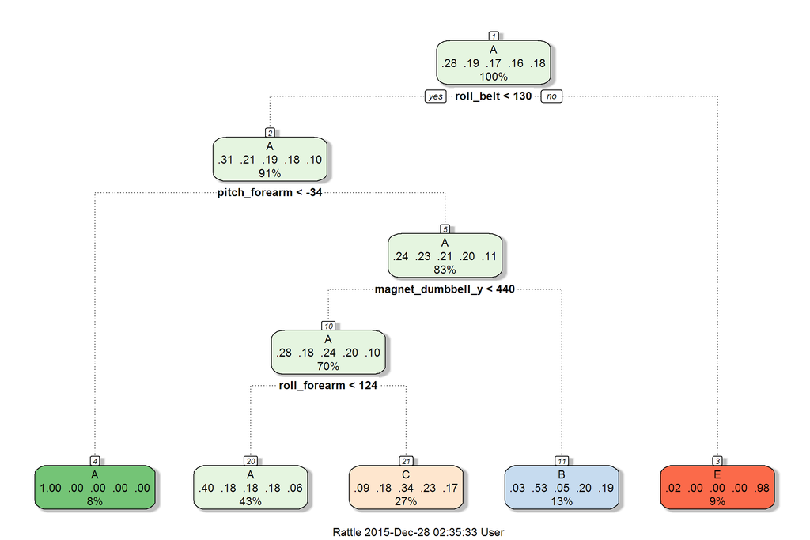

```r
rattle::fancyRpartPlot(cartFit1$finalModel)
```

### Evaluation of CART model via the Accuracy criterion

We looked closely into the predictivity of the CART model on test values by doing the following:

```r
predictions <- predict(cartFit1, trainData_test1)
confusionMatrix(predictions, trainData_test1$classe)
```

```
## Confusion Matrix and Statistics
##
##           Reference
## Prediction   A   B   C   D   E
##          A 251  80  88  79  28
##          B   4  54   5  24  20
##          C  17  56  78  58  46
##          D   0   0   0   0   0
##          E   7   0   0   0  87
##
## Overall Statistics
##
##                Accuracy : 0.4786
##                  95% CI : (0.447, 0.5104)
##     No Information Rate : 0.2841
##     P-Value [Acc > NIR] : < 2.2e-16
##
##                   Kappa : 0.3174
##  Mcnemar's Test P-Value : NA
##
## Statistics by Class:
##
##                      Class: A Class: B Class: C Class: D Class: E
## Sensitivity            0.8996  0.28421  0.45614    0.000  0.48066
## Specificity            0.6088  0.93308  0.78175    1.000  0.99126
## Pos Pred Value         0.4772  0.50467  0.30588      NaN  0.92553
## Neg Pred Value         0.9386  0.84457  0.87208    0.836  0.89414
## Prevalence             0.2841  0.19348  0.17413    0.164  0.18432
## Detection Rate         0.2556  0.05499  0.07943    0.000  0.08859
## Detection Prevalence   0.5356  0.10896  0.25967    0.000  0.09572
## Balanced Accuracy      0.7542  0.60865  0.61895    0.500  0.73596
```

It is realised that the Accuracy value is below 80% – not favorable in predictivity of a model. When we further tested this on 4 other sliced training datasets, with their respective test values, we tabled each Accuracy as following. All the Accuracies found are roughly within the range of 45-50%.

```r
tableAccuracy
```

```
##    Accuracy
## 1 0.4786151
## 2 0.4959184
## 3 0.5005097
## 4 0.4877551
## 5 0.4740061
```

### Training the data to RF model

```r
rfFit1 <- train(classe~., method="rf", prox=T, data=trainData_train1)
```

```r
print(rfFit1, digit=3)
```

[output not shown]

### Evaluation of RF model via the Accuracy criterion

Again, we looked closely into the predictivity of the RF model on test values by doing the following:

```r
predictions <- predict(rfFit1, trainData_test1)
confusionMatrix(predictions, trainData_test1$classe)
```

```
## Confusion Matrix and Statistics
##
##           Reference
## Prediction   A   B   C   D   E
##          A 277   4   0   2   0
##          B   1 183   5   2   1
##          C   1   3 163   3   2
##          D   0   0   3 153   1
##          E   0   0   0   1 177
##
## Overall Statistics
##
##                Accuracy : 0.9705
##                  95% CI : (0.9579, 0.9801)
##     No Information Rate : 0.2841
##     P-Value [Acc > NIR] : < 2.2e-16
##
##                   Kappa : 0.9626
##  Mcnemar's Test P-Value : NA
##
## Statistics by Class:
##
##                      Class: A Class: B Class: C Class: D Class: E
## Sensitivity            0.9928   0.9632   0.9532   0.9503   0.9779
## Specificity            0.9915   0.9886   0.9889   0.9951   0.9988
## Pos Pred Value         0.9788   0.9531   0.9477   0.9745   0.9944
## Neg Pred Value         0.9971   0.9911   0.9901   0.9903   0.9950
## Prevalence             0.2841   0.1935   0.1741   0.1640   0.1843
## Detection Rate         0.2821   0.1864   0.1660   0.1558   0.1802
## Detection Prevalence   0.2882   0.1955   0.1752   0.1599   0.1813
## Balanced Accuracy      0.9921   0.9759   0.9711   0.9727   0.9883
```

There is a high accuracy (more than 80%) in the model. Similarly, we further tested the RF model on 4 other training datasets, with their respective test values. The accuracy values are tabulated.

```r
tableAccuracy_RF
```

```
##   Accuracy_RF
## 1   0.9704684
## 2   0.9622449
## 3   0.9592253
## 4   0.9642857
## 5   0.9663609
```

### Evaluation of RF model with preprocessing and cross-validation

We now build the RF models with preprocessing by normalising through `center` and `scale` methods, and with cross-validation through `cv` method. Again the accuracy values are tabulated. The accuracy for each prediction model is recorded in the following table. As you may notice, it is almost the same as the accuracy for purely RF models.

Due to this, we have decided to go with the refined RF models for our prediction process.

```r
rfFit1 <- train(classe~., method="rf", prox=T,
               trControl=trainControl(method = "cv", number = 4),
               preProcess=c("center", "scale"),
               data=trainData_train1)
predictions <- predict(rfFit1, trainData_test1)
confusionMatrix(predictions, trainData_test1$classe)$overall
```

```r
tableAccuracy_RFcvnorm
```

```
##   Accuracy_RFcvnorm
## 1         0.9704684
## 2         0.9581633
## 3         0.9571865
## 4         0.9632653
## 5         0.9673802
```

## Analysing the Accuracy Values

The out-of-sample error is the error generated from applying prediction algorithm to a new dataset. In our case, we define it as `1-Accuracy`, numbers as shown below.

```
##   Accuracy_CART Accuracy_RF Accuracy_RFcvnorm Error Rate
## 1     0.4786151   0.9704684         0.9704684 0.02953157
## 2     0.4959184   0.9622449         0.9581633 0.04183673
## 3     0.5005097   0.9592253         0.9571865 0.04281346
## 4     0.4877551   0.9642857         0.9632653 0.03673469
## 5     0.4740061   0.9663609         0.9673802 0.03261978
```

## Conclusion

With 5 RF fitting models applied to predict the 20 items in the testing set, here is what we have found:

```
##    Fit1 Fit2 Fit3 Fit4 Fit5 Problem_id
## 1     B    B    B    B    B          1
## 2     A    A    A    A    A          2
## 3     B    A    B    B    A          3
## 4     A    A    A    A    A          4
## 5     A    A    A    A    A          5
## 6     E    E    E    E    E          6
## 7     D    D    D    D    D          7
## 8     D    D    B    B    D          8
## 9     A    A    A    A    A          9
## 10    A    A    A    A    A         10
## 11    B    B    B    B    C         11
## 12    C    C    C    C    C         12
## 13    B    B    B    B    B         13
## 14    A    A    A    A    A         14
## 15    E    E    E    E    E         15
## 16    E    E    E    E    E         16
## 17    A    A    A    A    A         17
## 18    B    B    B    B    B         18
## 19    B    B    B    B    B         19
## 20    B    B    B    B    B         20
```